# W3cubDocs

/Qt

# Saving, Previewing and Printing Forms in Qt Designer

Although *Qt Designer*'s forms are accurate representations of the components being edited, it is useful to preview the final appearance while editing. This feature can be activated by opening the **Form** menu and selecting **Preview**, or by pressing **Ctrl+R** when in the form.

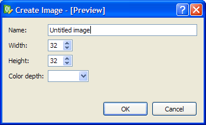

The preview shows exactly what the final component will look like when used in an application.

Since Qt 4.4, it is possible to preview forms with various skins - default skins, skins created with Qt Style Sheets or device skins. This feature simulates the effect of calling `QApplication::setStyleSheet()` in the application.

To preview your form with skins, open the **Edit** menu and select **Preferences...**

You will see the dialog shown below:

[figure not shown]

The **Print/Preview Configuration** checkbox must be checked to activate previews of skins. You can select the styles provided from the **Style** drop-down box.

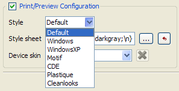

Alternatively, you can preview custom style sheet created with Qt Style Sheets. The figure below shows an example of Qt Style Sheet syntax and the corresponding output.

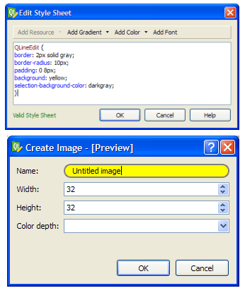

Another option would be to preview your form with device skins. A list of generic device skins are available in *Qt Designer*, however, you may also use other QVFB skins with the **Browse...** option.

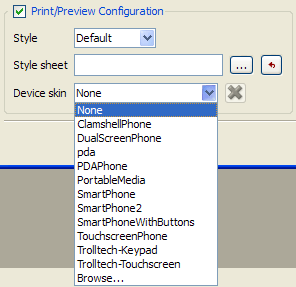

## Viewing the Form's Code

Since Qt 4.4, it is possible to view code generated by the User Interface Compiler (uic) for the *Qt Designer* form.

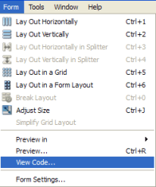

Select **View Code...** from the **Form** menu and a dialog with the generated code will be displayed. The screenshot below is an example of code generated by the `uic`.

[figure not shown]

## Saving and Printing the Form

Forms created in *Qt Designer* can be saved to an image or printed.

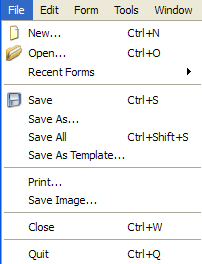

**Saving Forms**

To save a form as an image, choose the **Save Image...** option. The file will be saved in `.png` format.

**Printing Forms**

To print a form, select the **Print...** option.

© The Qt Company Ltd  
Licensed under the GNU Free Documentation License, Version 1.3.  
https://doc.qt.io/qt-6.2/designer-preview.html